# LDA／QDA 分析報告

本分析以 4 個預測變數（花萼長度、花萼寬度、花瓣長度、花瓣寬度）預測 Species（鳶尾花品種）的 3 個類別（setosa、versicolor、virginica），並比較 LDA 與 QDA 的分類表現。

整體狀態：完成。  
模型分析：完成；假設診斷：完成。

## 資料與設定

- 資料說明：R datasets::iris 原樣匯出；150 朵鳶尾花，三個品種各 50 朵（Anderson 1935 採集，Fisher 1936 分析）
- 分類變數：Species
- 預測變數：Sepal.Length、Sepal.Width、Petal.Length、Petal.Width
- 樣本數：150
- 驗證方式：重複分層 5-fold 交叉驗證 10 次（共 50 輪練習／考試）；隨機種子：2026
- 主要指標：Macro recall（各類別召回率的等權平均，即平衡正確率）。
- 先驗機率：由各訓練折的類別比例估計。
- 資料處理：未刪除觀測值、未插補缺失值或轉換變數。
- 軟體：R version 4.3.3 (2024-02-29)；MASS 7.3.60.0.1；診斷：base R (Mardia 1970; Box's M chi-square approximation)

### 各類別筆數

下表是每個類別（Y）各有幾筆資料。各類筆數差很多時，整體正確率會被筆數多的類別主導，所以本報告以 Macro recall 為主要指標。

| 類別 | 筆數 | 比例 |
| --- | --- | --- |
| setosa | 50 | 33.3% |
| versicolor | 50 | 33.3% |
| virginica | 50 | 33.3% |

### 變數介紹

下表說明每個欄位的意思與單位。「角色」欄：X（預測變數）是用來判斷的欄位，Y（分類變數）是要分的類別。

| 欄位 | 說明 | 單位 | 角色 | 型態 | 缺失數 |
| --- | --- | --- | --- | --- | --- |
| Sepal.Length | 花萼長度 | cm | X（預測變數） | numeric | 0 |
| Sepal.Width | 花萼寬度 | cm | X（預測變數） | numeric | 0 |
| Petal.Length | 花瓣長度 | cm | X（預測變數） | numeric | 0 |
| Petal.Width | 花瓣寬度 | cm | X（預測變數） | numeric | 0 |
| Species | 鳶尾花品種（setosa、versicolor、virginica） |  | Y（分類變數） | character | 0 |

## 資料檢查

以下只做標記與說明，不刪除或轉換任何資料（缺失值處理另見下一節）。每一列是一項檢查：「結果」是檢查出的數字，「說明」寫這個數字代表什麼。

| 檢查項目 | 結果 | 說明 |
| --- | --- | --- |
| 觀測筆數 | 150 | 分析用的資料筆數（3 類、4 個 X） |
| 重複筆數 | 1 | Y 和 X 都與其他列完全相同的筆數（數值相同不必然代表同一個體或標本；本次保留，是否為重複登錄仍需依原始紀錄確認） |
| 類別筆數比 | 1 | 最多類 ÷ 最少類；1 代表各類一樣多，大於 1.5 時不要只看正確率 |
| 筆數太少的類別數 | 0 | 筆數 ≤ X 個數的類別數；不是 0 時，QDA 無法估計這些類別 |
| 類內沒有變化的組合數 | 0 | 某類別在某個變數上全部同值的組合數；不是 0 時模型可能算不出來 |
| X 沒有完全線性相依 | 是 | 是＝未發現完全線性相依，但變數之間仍可能高度相關；否＝某個 X 可由其他 X 完全算出，LDA／QDA 無法計算 |
| 疑似離群筆數 | 13 | 在各類別內，任一變數超出 1.5 倍四分位距（IQR）的筆數；只標記，全部保留 |

## 模型驗證表現

怎麼看這張表：每一列是一個方法，分數都是 10 次重複的平均。「平均正確率」是全部資料猜對的比例；「平均 Macro recall」是先算每一類各自猜對的比例再平均，每一類一樣重要，是本報告選方法的依據；「Macro recall 標準差」越小，代表換一種隨機分組結果也差不多（它是切分之間的變動，不是信賴區間）；「平均 Macro-F1」同時考慮漏抓和誤判；「平均答對筆數」是每次重複 150 筆中答對幾筆，「最少／最多答對」是 10 次中的範圍；「預測涵蓋率」是成功給出預測的比例，正常是 100%。

| 模型 | 模型狀態 | 預測涵蓋率 | 平均正確率 | 平均 Macro recall | Macro recall 標準差 | 平均 Macro-F1 | 平均答對筆數 | 最少答對 | 最多答對 |
| --- | --- | --- | --- | --- | --- | --- | --- | --- | --- |
| LDA | 驗證完整 | 100.00% | 97.93% | 97.93% | 0.21% | 97.93% | 146.9 | 146 | 147 |
| QDA | 驗證完整 | 100.00% | 97.33% | 97.33% | 0.54% | 97.33% | 146.0 | 145 | 147 |

10 次重複的結果：LDA 每次平均答對 146.9／150 筆（範圍 146–147，平均 Macro recall 97.93%）；QDA 每次平均答對 146.0／150 筆（範圍 145–147，平均 Macro recall 97.33%）。逐次比較 Macro recall：LDA 較高 6 次、QDA 較高 0 次、相同 4 次。LDA 平均較高，選 LDA。10 次中沒有一次由 QDA 較高；平均差 0.9 筆。  
選定後，用全部 150 筆資料重新配適 LDA，作為最終模型（final_model.rds）。  
選擇規則：兩種方法用相同的切分，做 10 次分層 5-fold 交叉驗證（每次重新隨機分組），比較 10 次的平均 Macro recall，較高者勝出；完全相同時選較簡單的 LDA。逐次勝出次數只用來說明結果穩不穩定。Mardia、Box's M 只作診斷參考，不用來選方法。

每次重複中，每筆觀測恰好被預測一次。必須完成全部重複的模型才參加比較，驗證不完整的模型不提供分數。  
這組交叉驗證同時用於比較模型，分數不是獨立測試表現。

## 每一次重複的結果

每一次重複都把資料重新隨機分成 5 份；下表看得出分數隨切分變動多少，以及哪個方法較常勝出。每一列是一次重複：「答對」是 150 筆中答對幾筆，「較高」是該次 Macro recall 較高的方法。

| 第幾次 | LDA 答對 | LDA Macro recall | QDA 答對 | QDA Macro recall | 較高 |
| --- | --- | --- | --- | --- | --- |
| 1 | 147 | 0.98 | 146 | 0.9733 | LDA |
| 2 | 147 | 0.98 | 147 | 0.98 | 相同 |
| 3 | 147 | 0.98 | 145 | 0.9667 | LDA |
| 4 | 147 | 0.98 | 147 | 0.98 | 相同 |
| 5 | 147 | 0.98 | 147 | 0.98 | 相同 |
| 6 | 147 | 0.98 | 146 | 0.9733 | LDA |
| 7 | 146 | 0.9733 | 146 | 0.9733 | 相同 |
| 8 | 147 | 0.98 | 145 | 0.9667 | LDA |
| 9 | 147 | 0.98 | 145 | 0.9667 | LDA |
| 10 | 147 | 0.98 | 146 | 0.9733 | LDA |

## 各類別表現

把 10 次重複的預測合併計算（每筆觀測被預測 10 次）。每一列是一個方法在一個類別的表現：「召回率」是這一類的資料有多少比例被正確認出；「精確率」是被預測成這一類的資料中，真的屬於這一類的比例；「F1」是兩者的綜合。越接近 100% 越好；某一類特別低，代表這一類容易被認錯。

本資料：兩種方法對 setosa 的召回率與精確率皆為 100%。LDA 對 versicolor 的召回率為 96.00%，高於 QDA 的 93.80%；QDA 對 virginica 的召回率為 98.20%，高於 LDA 的 97.80%。

| 模型 | 類別 | 召回率 recall | 精確率 precision | F1 |
| --- | --- | --- | --- | --- |
| LDA | setosa | 100.00% | 100.00% | 100.00% |
| LDA | versicolor | 96.00% | 97.76% | 96.87% |
| LDA | virginica | 97.80% | 96.07% | 96.93% |
| QDA | setosa | 100.00% | 100.00% | 100.00% |
| QDA | versicolor | 93.80% | 98.12% | 95.91% |
| QDA | virginica | 98.20% | 94.06% | 96.09% |

混淆矩陣以列百分比呈現：每一列是一個真實類別，數字是被預測成各類別的比例，每一列加起來是 100%。對角線（列與欄是同一類）就是該類別的召回率，其他格子是誤判的去向。

例如 LDA 表中，versicolor 那一列、virginica 那一欄是 4.0%：真實是 versicolor 的資料，有 4.0% 被誤判成 virginica（這是誤判比例最高的一格）。  
誤判全部發生在 versicolor 與 virginica 之間（LDA：versicolor 被誤判為 virginica 4.0%，virginica 被誤判為 versicolor 2.2%；QDA：versicolor 被誤判為 virginica 6.2%，virginica 被誤判為 versicolor 1.8%）。

### 混淆矩陣：LDA

| 真實類別 \ 預測類別 | setosa | versicolor | virginica |
| --- | --- | --- | --- |
| setosa | 100.0% | 0.0% | 0.0% |
| versicolor | 0.0% | 96.0% | 4.0% |
| virginica | 0.0% | 2.2% | 97.8% |

### 混淆矩陣：QDA

| 真實類別 \ 預測類別 | setosa | versicolor | virginica |
| --- | --- | --- | --- |
| setosa | 100.0% | 0.0% | 0.0% |
| versicolor | 0.0% | 93.8% | 6.2% |
| virginica | 0.0% | 1.8% | 98.2% |

## 假設診斷

Mardia 檢查每一類的資料是否接近多元常態（鐘形）：Skewness（偏態）看分布是否不對稱，Kurtosis（峰態）看尾巴是否太厚或太薄。Box's M 檢查各類資料的散開程度與方向（共變異數矩陣）是否相同，是所有類別一起做的檢定（組別 ALL）。p 值 < 0.05 稱為「顯著」，表示有證據違反該假設；p ≥ 0.05 表示沒有看到明顯違反。

| 診斷 | 組別 | 樣本數 | 統計量 | p 值 | 狀態 | 備註 |
| --- | --- | --- | --- | --- | --- | --- |
| Mardia Skewness | setosa | 50 | 25.66 | 0.1772 | 已計算 |  |
| Mardia Kurtosis | setosa | 50 | 1.295 | 0.1953 | 已計算 |  |
| Mardia Skewness | versicolor | 50 | 25.19 | 0.1944 | 已計算 |  |
| Mardia Kurtosis | versicolor | 50 | -0.5719 | 0.5674 | 已計算 |  |
| Mardia Skewness | virginica | 50 | 26.27 | 0.1571 | 已計算 |  |
| Mardia Kurtosis | virginica | 50 | 0.1526 | 0.8787 | 已計算 |  |
| Box M | ALL | 150 | 140.9 | 3.352e-20 | 已計算 | df = 20 |

檢定不顯著不代表假設已被證明；無法估計時，不產生替代 p 值。  
Box's M 對非常態很敏感；樣本量增加時可能偵測到較小的差異，應結合驗證表現解讀。  
診斷結果用於說明適用性，不直接依單一 p 值決定 LDA／QDA。

### Mardia 與 Box's M 的合併解讀

依 Mardia 和 Box's M 是否顯著分成四種情況，標「← 本資料」的那一列就是本資料的情況。

| Mardia | Box's M | 解讀 | 本資料 |
| --- | --- | --- | --- |
| 不顯著 | 不顯著 | 未發現明顯違反假設；仍依交叉驗證結果選方法。 |  |
| 不顯著 | 顯著 | 各類散開方式可能不同，QDA 有機會較好。 | ← 本資料 |
| 顯著 | 不顯著 | 資料不像鐘形，算出的機率可能不準。 |  |
| 顯著 | 顯著 | Box's M 可能只是受非鐘形影響，不能直接下結論。 |  |

合併解讀：Mardia 不顯著、Box's M 顯著——各類散開方式可能不同，QDA 有機會較好。

### 對照實際驗證結果

Mardia 檢定：3 個類別的偏態與峰態均未達顯著（p 值 0.157–0.879）。這只表示沒有看到明顯違反，不代表已證明多元常態成立。  
Box's M 顯著（χ² 近似統計量 140.9，df = 20，p = 3.35e-20），表示「各類共變異數矩陣相同」的假設受到質疑；但 Box's M 對非常態敏感，樣本量增加時也可能偵測到較小的差異，應結合驗證表現解讀。  
但 QDA 的實際驗證表現沒有更好（平均 Macro recall：QDA 97.33%，LDA 97.93%），因此仍依交叉驗證結果選擇 LDA。一種可能的解釋是：QDA 比 LDA 多估計 20 個參數，允許各類共變異數不同的好處，可能被估計誤差抵消。  
診斷用來說明假設是否合理，不改變選模規則。

## 分組描述統計

每一列是某一類別在某個變數上的摘要：平均數、標準差（資料散開的程度）、最小值、中位數、最大值。同一個變數在不同類別的平均數差越多、標準差越小，單看這個變數時越能區分類別；這是逐一變數的描述，不代表該變數在多變數模型中的獨立貢獻。

| 類別 | 變數 | 筆數 | 平均數 | 標準差 | 最小值 | 中位數 | 最大值 |
| --- | --- | --- | --- | --- | --- | --- | --- |
| setosa | Sepal.Length | 50 | 5.006 | 0.3525 | 4.3 | 5 | 5.8 |
| setosa | Sepal.Width | 50 | 3.428 | 0.3791 | 2.3 | 3.4 | 4.4 |
| setosa | Petal.Length | 50 | 1.462 | 0.1737 | 1 | 1.5 | 1.9 |
| setosa | Petal.Width | 50 | 0.246 | 0.1054 | 0.1 | 0.2 | 0.6 |
| versicolor | Sepal.Length | 50 | 5.936 | 0.5162 | 4.9 | 5.9 | 7 |
| versicolor | Sepal.Width | 50 | 2.77 | 0.3138 | 2 | 2.8 | 3.4 |
| versicolor | Petal.Length | 50 | 4.26 | 0.4699 | 3 | 4.35 | 5.1 |
| versicolor | Petal.Width | 50 | 1.326 | 0.1978 | 1 | 1.3 | 1.8 |
| virginica | Sepal.Length | 50 | 6.588 | 0.6359 | 4.9 | 6.5 | 7.9 |
| virginica | Sepal.Width | 50 | 2.974 | 0.3225 | 2.2 | 3 | 3.8 |
| virginica | Petal.Length | 50 | 5.552 | 0.5519 | 4.5 | 5.55 | 6.9 |
| virginica | Petal.Width | 50 | 2.026 | 0.2747 | 1.4 | 2 | 2.5 |

## 圖

每張圖下方都有怎麼看的說明。

### 圖 1：各類別筆數

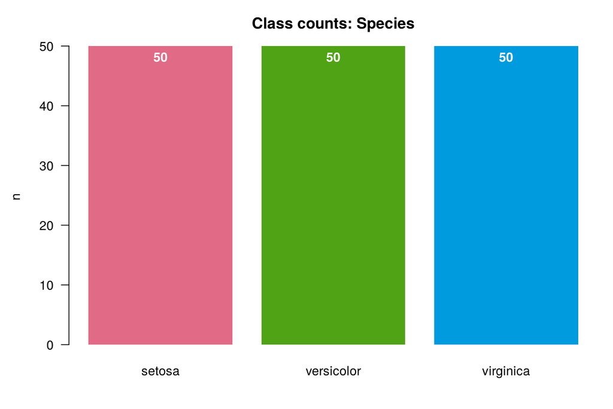

01_class_counts.png

長條高度是每個類別的筆數（數字標在長條內），用來看各類是否差不多多。本資料最多與最少類別的筆數比是 1，算是平衡。

### 圖 2：各變數的分組箱形圖

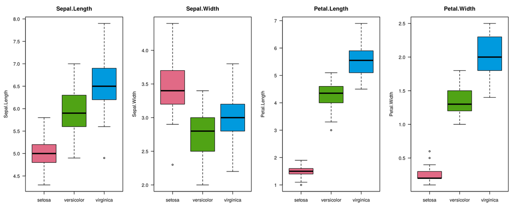

02_boxplots.png

每一小張是一個變數，每個箱子是一個類別。箱子涵蓋中間 50% 的資料，中間的粗線是中位數，上下延伸的線是一般範圍，線外的圓點是可能的離群值。同一張小圖中，不同類別的箱子位置差越多、重疊越少，代表單看這個變數時越能把類別分開；箱子高矮差很多，代表各類散開的程度不同。本資料：setosa 在花瓣長度（Petal.Length）、花瓣寬度（Petal.Width）的範圍與其他類別完全沒有重疊（例如 Petal.Length：setosa 最大 1.9，其他類別最小 3）；versicolor 與 virginica 在全部 4 個變數上的範圍都有重疊。這是逐一變數的比較，不代表該變數在多變數模型中的獨立貢獻最大。

### 圖 3：各類別、各變數的常態 Q-Q 圖

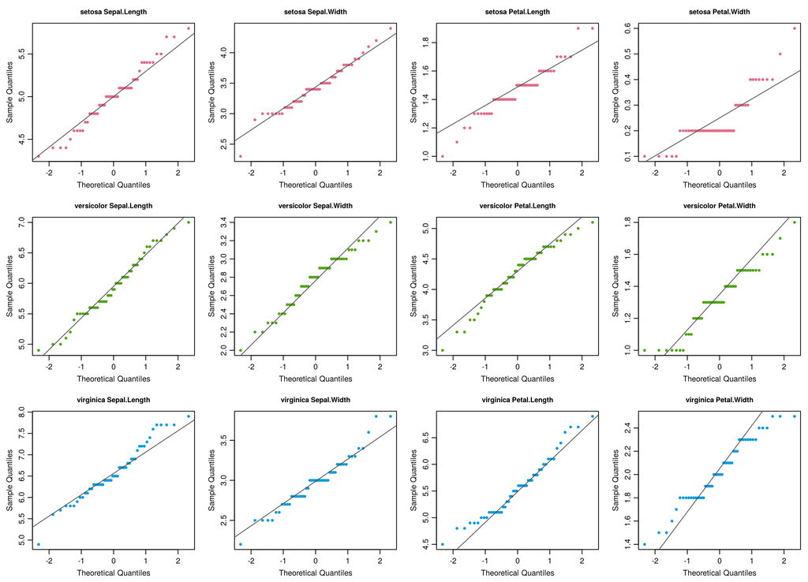

03_qq_by_class.png

每一列是一個類別、每一欄是一個變數。橫軸是「如果資料是常態分布，理論上該在的位置」，縱軸是實際資料。點大致貼著灰色直線，代表這個變數在這一類接近常態（鐘形）；兩端明顯往上翹或往下彎，代表偏態或尾巴較厚。點排成一階一階，可能與量測精度有關（例如只量到小數一位），不能僅據此判定是否符合常態。這張圖一次只看一個變數；所有變數合起來是否接近多元常態，需綜合檢定、圖形與資料特性評估，不能僅由單一檢定判定。

### 圖 4：變數兩兩散布圖

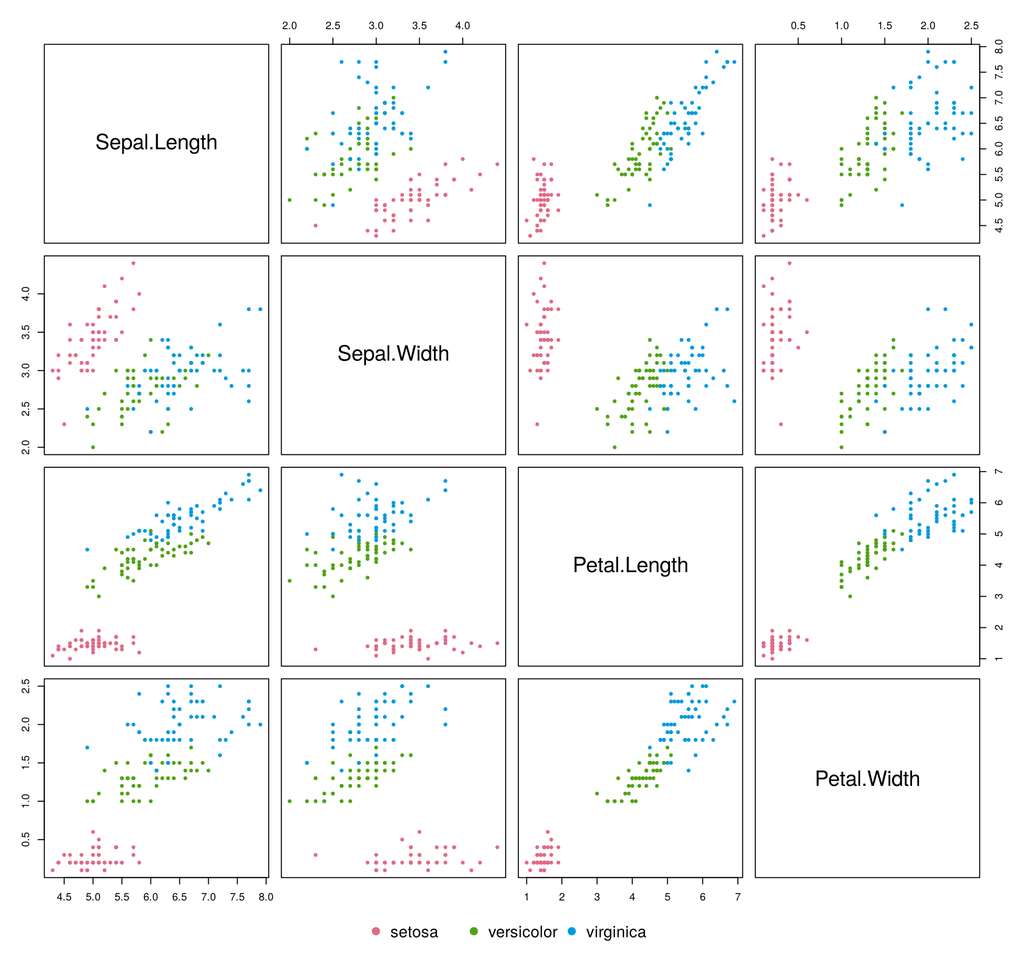

04_pairs.png

每一小格是兩個變數的散布圖：該格所在列的變數當縱軸、所在欄的變數當橫軸（變數名稱寫在對角線上），點的顏色代表類別（圖例在下方）。不同顏色的點群分得越開，代表這兩個變數合起來越能區分類別。各類點群的形狀、大小、傾斜方向越相似，LDA「各類散開方式相同」的假設越合理；差很多時，QDA 可能較好。

### 圖 5：LDA 判別分數圖

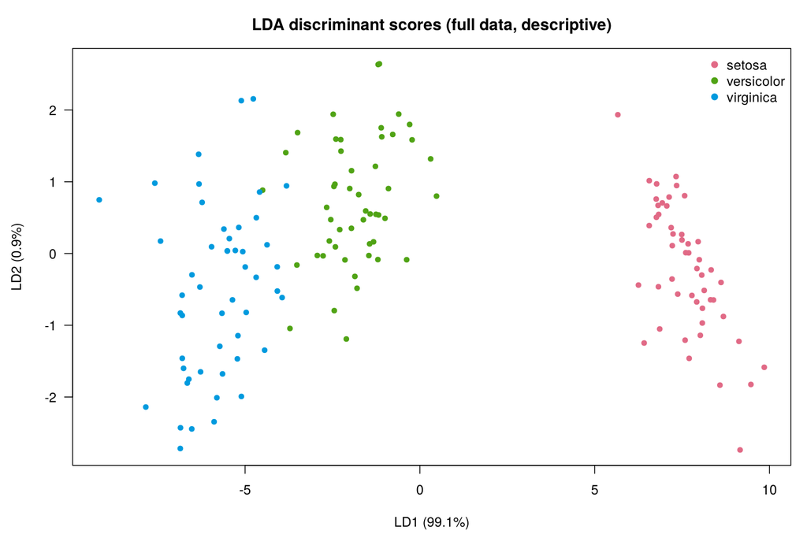

05_lda_scores.png

LDA 把所有 X 組合成新的座標軸（判別軸 LD1、LD2），讓不同類別盡量分開。每個點是一筆資料，顏色代表類別。括號裡的百分比是各判別軸的相對判別資訊比例（該軸的組間對組內變異比，占所有判別軸總和的比例）；本資料 LD1 占 99.1%，判別資訊幾乎都集中在 LD1 這個方向（橫軸）。這個百分比不是分類正確率，也不是原始資料的變異解釋率（與主成分分析不同）。點群分得越開、重疊越少，越容易分類；點群重疊的地方，通常也是容易誤判的類別。本圖以全部資料配適，只用來描述類別分得多開，不代表驗證表現。

### 圖 6：混淆矩陣熱圖

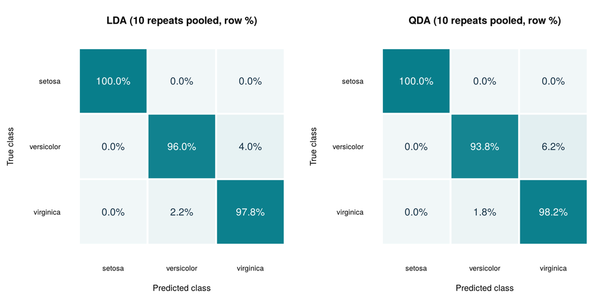

06_confusion_matrix.png

內容與上面的混淆矩陣表相同（10 次重複合併、列百分比），用顏色深淺表示比例；左右依序是 LDA、QDA。縱軸是真實類別、橫軸是預測類別；左上到右下的對角線是各類答對的比例，越深越好；對角線以外有顏色的格子就是誤判的去向。

## 模型警告與錯誤

模型執行過程沒有記錄到警告或錯誤；診斷未完成原因另見診斷表。

## 結論與討論

### 兩種方法的分類表現

LDA 平均 Macro recall 為 97.93%，QDA 為 97.33%，相差 0.60 個百分點，兩種方法的表現接近。  
以答對筆數來看，LDA 平均答對 146.9 筆（範圍 146–147），QDA 平均答對 146.0 筆（範圍 145–147）；LDA 每次 150 筆平均多答對 0.9 筆。  
10 次重複中，LDA 較高 6 次、相同 4 次、較低 0 次。

### 為什麼選擇 LDA

LDA 在本次交叉驗證中略優，因此依既定規則（10 次的平均 Macro recall 較高者勝出）選用 LDA。  
這是本資料、本次驗證設計下的比較，不是統計檢定；不代表 LDA 顯著優於 QDA，也不代表 LDA 在其他資料上普遍較好。10 次重複中 QDA 沒有一次較高，方向一致。  
選定後以全部 150 筆資料重新配適 LDA，作為最終模型（final_model.rds）。

### 哪些類別容易誤判

- 兩種方法對 setosa 的召回率與精確率皆為 100%。
- 誤判全部發生在 versicolor 與 virginica 之間（LDA：versicolor 被誤判為 virginica 4.0%，virginica 被誤判為 versicolor 2.2%；QDA：versicolor 被誤判為 virginica 6.2%，virginica 被誤判為 versicolor 1.8%）。
- LDA 對 versicolor 的召回率為 96.00%，高於 QDA 的 93.80%；QDA 對 virginica 的召回率為 98.20%，高於 LDA 的 97.80%。
- 描述統計中，setosa 在花瓣長度（Petal.Length）、花瓣寬度（Petal.Width）的範圍與其他類別完全沒有重疊（例如 Petal.Length：setosa 最大 1.9，其他類別最小 3）；versicolor 與 virginica 在全部 4 個變數上的範圍都有重疊。這些是逐一變數的描述，有助於理解誤判集中在哪些類別，但不代表個別變數在模型中的獨立貢獻最大。

### 假設診斷對結果的影響

Mardia 檢定在各類別均未達顯著，但這不代表已證明多元常態成立。Box's M 顯著，「各類共變異數相同」的假設受到質疑。但 QDA 的實際驗證表現沒有更好，因此仍依交叉驗證結果選擇 LDA；診斷只提醒 LDA 的等共變異數假設可能不完全成立。詳細數字見「假設診斷」一節。

### 限制

- 10 次重複使用的是同一批 150 筆觀測，只是切分方式不同，不代表有 1,500 筆獨立樣本。
- Macro recall 標準差是不同切分之間的變動，不是新資料預測表現的信賴區間。
- 同一組交叉驗證同時用於比較與選擇模型，分數不是獨立測試表現，可能略為樂觀。
- 尚無外部資料驗證；推廣到其他資料來源或採集條件，仍需進一步確認。
- 本報告沒有計算變數重要性或判別係數的不確定性，不宜據此判斷哪個變數最重要。
- 資料中有 1 筆與其他列的 Y 和 X 完全相同，已保留；數值相同不必然代表同一個體或標本，是否為重複登錄仍需依原始紀錄確認。
- 本版處理獨立觀測與數值型預測變數，使用重複分層交叉驗證（固定 5 折、10 次）。
- 各類別診斷有多個檢定，p 值以診斷用途呈現，未進行多重比較校正。